# ManyFaces pilot ratings

Rater demographics and interrater agreement

```r
library(psych) # ICC, alpha, omega
library(furrr) # run code parallel
library(tidyverse)

# Load custom functions
source("data/custom_functions.R")
```

## Load data

```r
# Rating data
data_exp <- read_csv("data/manyfaces-pilot-exp_cleaned.csv",
                     show_col_types = FALSE)

# Questionnaire data
data_qu <- read_csv("data/manyfaces-pilot-quest_cleaned.csv",
                    show_col_types = FALSE)
```

## Demographics

Demographic data is available for 1685 of the total of 1909 raters.

### Age and Gender

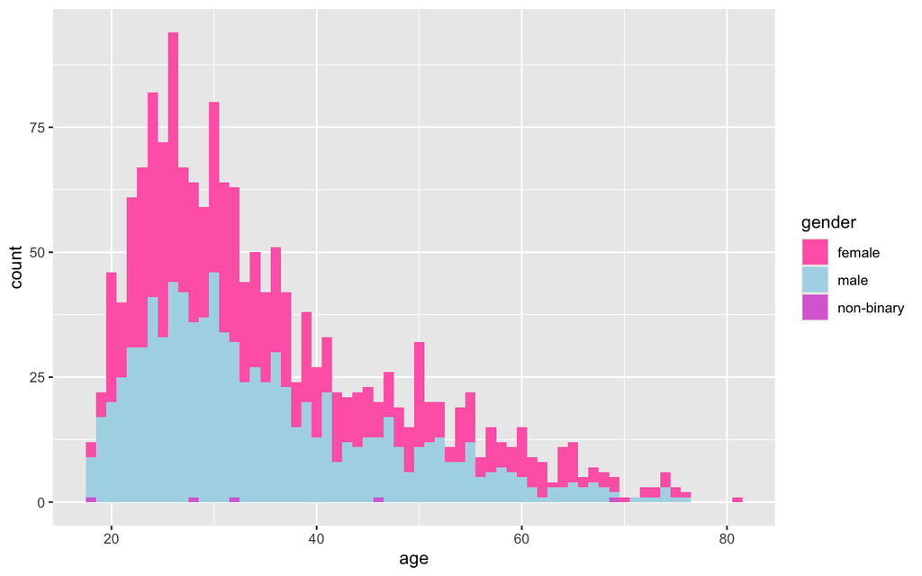

```r
data_qu |>
  ggplot(aes(x = age, fill = gender)) +
  geom_histogram(binwidth = 1) +
  scale_fill_manual(values = c("hotpink", "lightblue", "orchid", "gray"))
```

### Residence

```r
count(data_qu, residence, sort = TRUE)
```

| residence | n |
| --- | --- |
| ZA | 840 |
| GB | 256 |
| US | 221 |
| PL | 49 |
| PT | 44 |
| CA | 41 |
| ES | 34 |
| IT | 27 |
| KE | 26 |
| GR | 19 |

[output cut: 28 more lines]

### Ethnicity

```r
data_qu |>
  mutate(ethnicity = tolower(ethnicity)) |>
  count(ethnicity, sort = TRUE)
```

| ethnicity | n |
| --- | --- |
| black | 723 |
| white | 400 |
| african | 133 |
| caucasian | 66 |
| asian | 35 |
| black african | 33 |
| white british | 24 |
| white/caucasian | 18 |
| hispanic | 13 |
| latino | 12 |

[output cut: 123 more lines]

### Devices

```r
count(data_qu, device, sort = TRUE)
```

| device | n |
| --- | --- |
| laptop | 751 |
| desktop | 469 |
| phone | 425 |
| tablet | 38 |
| NA | 2 |

## Analyses

### Interrater agreement

```r
data_trait <- data_exp |>
  filter(exp == "attractive" | exp == "dominant"  | exp == "trustworthy"  | exp == "gender-typical"  | exp == "memorable") |>
  mutate(dv = as.numeric(dv))

data_trait_unstd <- data_exp |>
  filter(grepl("unstd", exp)) |>
  mutate(dv = as.numeric(dv))

data_emotion_int <- data_exp |>
  filter(exp == "anger" | exp == "happiness"  | exp == "disgust"  | exp == "surprise"  | exp == "sadness" | exp == "fear") |>
  mutate(dv = as.numeric(dv))

data_emotion_cat <- data_exp |>
  # filter out emotion categorisation tasks
  filter(grepl("^em", exp))
```

#### ICC

##### Trait ratings

**Standardised**

```r
data_trait |>
  group_by(exp) |>
  group_map(calc_icc) |>
  bind_rows()
```

| experiment | ICC(2,1) | ICC(2,1): 95% CI lower | ICC(2,1): 95% CI upper | ICC(2,k) | ICC(2,k): 95% CI lower | ICC(2,k): 95% CI upper | n_raters | n_stimuli |
| --- | --- | --- | --- | --- | --- | --- | --- | --- |
| attractive | 0.13497732 | 0.10964612 | 0.16635986 | 0.9298901 | 0.9127982 | 0.9443283 | 85 | 205 |
| dominant | 0.06652584 | 0.05400071 | 0.08272386 | 0.8713058 | 0.8443073 | 0.8954795 | 95 | 205 |
| gender-typical | 0.06808685 | 0.05414862 | 0.08593029 | 0.8613079 | 0.8295298 | 0.8887742 | 85 | 205 |
| memorable | 0.01578320 | 0.01152600 | 0.02141175 | 0.5710020 | 0.4918217 | 0.6448939 | 83 | 205 |
| trustworthy | 0.07333410 | 0.05950841 | 0.09113439 | 0.8756721 | 0.8492014 | 0.8992369 | 89 | 205 |

**Unstandardised**

```r
data_trait_unstd |>
  group_by(exp) |>
  group_map(calc_icc) |>
  bind_rows()
```

| experiment | ICC(2,1) | ICC(2,1): 95% CI lower | ICC(2,1): 95% CI upper | ICC(2,k) | ICC(2,k): 95% CI lower | ICC(2,k): 95% CI upper | n_raters | n_stimuli |
| --- | --- | --- | --- | --- | --- | --- | --- | --- |
| attractive (unstd) | 0.12777281 | 0.10322200 | 0.15867940 | 0.9248413 | 0.9062676 | 0.9406283 | 84 | 188 |
| dominant (unstd) | 0.05088987 | 0.04050127 | 0.06457006 | 0.8373290 | 0.8020681 | 0.8688801 | 96 | 188 |
| trustworthy (unstd) | 0.06853001 | 0.05496970 | 0.08622573 | 0.8662087 | 0.8365668 | 0.8925179 | 88 | 188 |

###### ICC “corridors of stability”

At what sample size (if at all) do ratings reach acceptable reliability of .75 to .90?

```r
# Set seed for reproducibility
set.seed(123)

# Set a stable parallel plan
future::plan(multisession, workers = 3)

# Get unique experiments
experiments <- unique(data_trait$exp)

# Run the function in parallel across experiments
corridor_icc_list <- furrr::future_map(
  experiments,
  function(exp_name) {

    data_subset <- data_trait |>
      filter(exp == exp_name)

    calc_icc_cos(data = data_subset,
           exp = exp_name,
           n_raters_seq = seq(10, 100, 10),
           n_iter = 50)
  },
  .options = furrr::furrr_options(seed = TRUE)
)

# Combine all results into a single tibble
corridor_icc_summary <- list_rbind(corridor_icc_list)

# Reset plan to sequential
future::plan(sequential)
```

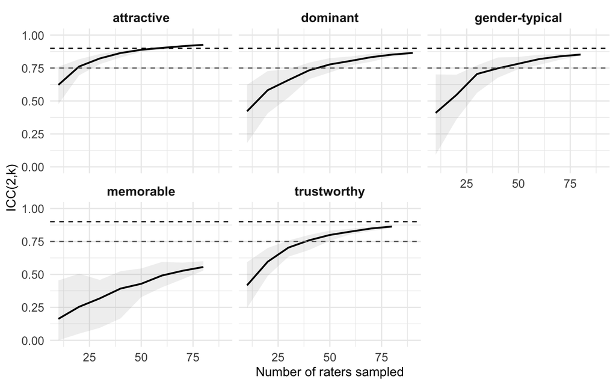

##### Emotion intensity

```r
data_emotion_int |>
  group_by(exp) |>
  group_map(calc_icc) |>
  bind_rows()
```

| experiment | ICC(2,1) | ICC(2,1): 95% CI lower | ICC(2,1): 95% CI upper | ICC(2,k) | ICC(2,k): 95% CI lower | ICC(2,k): 95% CI upper | n_raters | n_stimuli |
| --- | --- | --- | --- | --- | --- | --- | --- | --- |
| anger | 0.1902378 | 0.1568620 | 0.2311483 | 0.9523107 | 0.9405253 | 0.9623416 | 85 | 187 |
| disgust | 0.3496903 | 0.3036848 | 0.4031857 | 0.9801867 | 0.9756833 | 0.9841651 | 92 | 184 |
| fear | 0.2168572 | 0.1791767 | 0.2628217 | 0.9618298 | 0.9520712 | 0.9700990 | 91 | 175 |
| happiness | 0.3914727 | 0.3411874 | 0.4476891 | 0.9832050 | 0.9792218 | 0.9866243 | 91 | 199 |
| sadness | 0.1603719 | 0.1316105 | 0.1963094 | 0.9516286 | 0.9397967 | 0.9617719 | 103 | 183 |
| surprise | 0.3832482 | 0.3353165 | 0.4382257 | 0.9812021 | 0.9769457 | 0.9849683 | 84 | 184 |

#### Cronbach’s alpha and McDonald’s omega total

##### Trait ratings

**Standardised**

```r
data_trait |>
  group_by(exp) |>
  group_map(calc_alpha_omega) |>
  bind_rows()
```

[output not shown]

[output not shown]

[output not shown]

[output not shown]

[output not shown]

| experiment | alpha | omega_t | n_raters_initial | n_raters_final | n_raters_dropped_variability | dropped_raters_var | n_stimuli |
| --- | --- | --- | --- | --- | --- | --- | --- |
| attractive | 0.9585139 | 0.9647956 | 85 | 85 | 0 |  | 205 |
| dominant | 0.9004059 | 0.9157928 | 95 | 95 | 0 |  | 205 |
| gender-typical | 0.9137312 | 0.9329463 | 85 | 85 | 0 |  | 205 |
| memorable | 0.6465338 | 0.8696021 | 83 | 83 | 0 |  | 205 |
| trustworthy | 0.9062619 | 0.9252429 | 89 | 89 | 0 |  | 205 |

Wee note re warnings (turned off in output):

- “Number of categories should be increased…”: occurs when some raters use only a subset of the response scale; that is not unexpected in subjective ratings (note that we did filter out raters with <3 unique categories – see also below)
- “Some items were negatively correlated…”: potentially reflects true inter-rater disagreement; reversing raters not appropriate in this context
- “Omega_h… not meaningful”: omega_h is undefined when computing a one-factor solution; omega_t remains valid and is the relevant statistic reported.

**Unstandardised**

```r
data_trait_unstd |>
  group_by(exp) |>
  group_map(calc_alpha_omega) |>
  bind_rows()
```

[output not shown]

[output not shown]

[output not shown]

| experiment | alpha | omega_t | n_raters_initial | n_raters_final | n_raters_dropped_variability | dropped_raters_var | n_stimuli |
| --- | --- | --- | --- | --- | --- | --- | --- |
| attractive (unstd) | 0.9537448 | 0.9597182 | 84 | 84 | 0 |  | 188 |
| dominant (unstd) | 0.8766096 | 0.8978366 | 96 | 95 | 1 | 157816 | 188 |
| trustworthy (unstd) | 0.8975107 | 0.9192751 | 88 | 87 | 1 | 156116 | 188 |

Four participants responded with only two values but were not caught by our “overly consistent filter”. What do we want to do with them – just drop them here, or exclude them more generally (as part of exclusions)?

```r
unique_values_check <- data_exp |>
  # filter out emotion categorisation tasks
  filter(!grepl("^em", exp)) |>
  mutate(dv = as.numeric(dv))

unique_values_summary <- unique_values_check |>
  group_by(exp) |>
  group_map(~ {
    unique_counts <- check_unique_values(.x,
                                         col_map = list(p_id = "session_id",
                                                        trait = "exp",
                                                        stim_id = "trial_name",
                                                        rating = "dv"))
    tibble(
      exp = .y$exp,
      rater = names(unique_counts),
      n_unique = unique_counts
    )
  }) |>
  bind_rows()

unique_values_summary |> filter(n_unique < 3)
```

| exp | rater | n_unique |
| --- | --- | --- |
| anger | 156209 | 2 |
| disgust | 156243 | 2 |
| dominant (unstd) | 157816 | 2 |
| trustworthy (unstd) | 156116 | 2 |

##### Emotion intensity

```r
data_emotion_int |>
  group_by(exp) |>
  group_map(calc_alpha_omega) |>
  bind_rows()
```

[output not shown]

[output not shown]

[output not shown]

[output not shown]

[output not shown]

[output not shown]

| experiment | alpha | omega_t | n_raters_initial | n_raters_final | n_raters_dropped_variability | dropped_raters_var | n_stimuli |
| --- | --- | --- | --- | --- | --- | --- | --- |
| anger | 0.9698274 | 0.9724018 | 85 | 84 | 1 | 156209 | 187 |
| disgust | 0.9842327 | 0.9854675 | 92 | 91 | 1 | 156243 | 184 |
| fear | 0.9764375 | 0.9795130 | 91 | 91 | 0 |  | 175 |
| happiness | 0.9888546 | 0.9907950 | 91 | 91 | 0 |  | 199 |
| sadness | 0.9698972 | 0.9734162 | 103 | 103 | 0 |  | 183 |
| surprise | 0.9847858 | 0.9866504 | 84 | 84 | 0 |  | 184 |